# Cyclistic analysis

Fernando

2022-08-23

# Cyclistic trips analysis

This case study is about a bike share company. The company has flexible pricing plans: single-ride passes, full-day passes and annual memberships. Clients buying the first two plans will be referred as casual riders while clients with annual memberships will be referred as Cyclistic members. The finance team has concluded that annual memberships are more profitable for the company, and future growth of it will rely on maximizing annual memberships. The goal of the company is to design marketing campaigns to convert casual riders into Cyclistic members. With this goal, three questions will guide the marketing campaign:

- How do annual members and casual riders use Cyclistic bikes differently?
- Why would casual riders buy Cyclistic annual membership?
- How can Cyclistic use digital media to influence casual riders to become members?

## Data source:

Data was given from the company research team, as monthly trips in .csv format. It comprises the last year trips, including different aspects of the trip and the kind of client: member or casual.

# Data analysis with “R”

### installing libraries needed

```r
library(tidyverse)
```

```r
library(ggplot2)
library(lubridate)
library(geosphere)
library(dplyr)
library(ggstatsplot)
library(sp)
library(rgdal)
```

### Importing data

```r
trips.2021.06<-read.csv("202106-divvy-tripdata.csv")
trips.2021.07<-read.csv("202107-divvy-tripdata.csv")
trips.2021.08<-read.csv("202108-divvy-tripdata.csv")
trips.2021.09<-read.csv("202109-divvy-tripdata.csv")
trips.2021.10<-read.csv("202110-divvy-tripdata.csv")
trips.2021.11<-read.csv("202111-divvy-tripdata.csv")
trips.2021.12<-read.csv("202112-divvy-tripdata.csv")
trips.2022.01<-read.csv("202201-divvy-tripdata.csv")
trips.2022.02<-read.csv("202202-divvy-tripdata.csv")
trips.2022.03<-read.csv("202203-divvy-tripdata.csv")
trips.2022.04<-read.csv("202204-divvy-tripdata.csv")
trips.2022.05<-read.csv("202205-divvy-tripdata.csv")
```

### Agregating data in one dataframe

```r
raw.trips<- rbind(trips.2021.06, trips.2021.07, trips.2021.08, trips.2021.09,
                   trips.2021.10, trips.2021.11, trips.2021.12, trips.2022.01,
                   trips.2022.02, trips.2022.03, trips.2022.04, trips.2022.05)
```

### Data general structure

```r
glimpse(raw.trips)
```

```
## Rows: 5,860,776
## Columns: 13
## $ ride_id            <chr> "99FEC93BA843FB20", "06048DCFC8520CAF", "9598066F68~
## $ rideable_type      <chr> "electric_bike", "electric_bike", "electric_bike", ~
## $ started_at         <chr> "2021-06-13 14:31:28", "2021-06-04 11:18:02", "2021~
## $ ended_at           <chr> "2021-06-13 14:34:11", "2021-06-04 11:24:19", "2021~
## $ start_station_name <chr> "", "", "", "", "", "", "", "", "", "", "", "", "",~
## $ start_station_id   <chr> "", "", "", "", "", "", "", "", "", "", "", "", "",~
## $ end_station_name   <chr> "", "", "", "", "", "", "", "", "", "Michigan Ave &~
## $ end_station_id     <chr> "", "", "", "", "", "", "", "", "", "13042", "", ""~
## $ start_lat          <dbl> 41.80, 41.79, 41.80, 41.78, 41.80, 41.78, 41.79, 41~
## $ start_lng          <dbl> -87.59, -87.59, -87.60, -87.58, -87.59, -87.58, -87~
## $ end_lat            <dbl> 41.80000, 41.80000, 41.79000, 41.80000, 41.79000, 4~
## $ end_lng            <dbl> -87.6000, -87.6000, -87.5900, -87.6000, -87.5900, -~
## $ member_casual      <chr> "member", "member", "member", "member", "member", "~
```

```r
str(raw.trips)
```

```
## 'data.frame':    5860776 obs. of  13 variables:
##  $ ride_id           : chr  "99FEC93BA843FB20" "06048DCFC8520CAF" "9598066F68045DF2" "B03C0FE48C412214" ...
##  $ rideable_type     : chr  "electric_bike" "electric_bike" "electric_bike" "electric_bike" ...
##  $ started_at        : chr  "2021-06-13 14:31:28" "2021-06-04 11:18:02" "2021-06-04 09:49:35" "2021-06-03 19:56:05" ...
##  $ ended_at          : chr  "2021-06-13 14:34:11" "2021-06-04 11:24:19" "2021-06-04 09:55:34" "2021-06-03 20:21:55" ...
##  $ start_station_name: chr  "" "" "" "" ...
##  $ start_station_id  : chr  "" "" "" "" ...
##  $ end_station_name  : chr  "" "" "" "" ...
##  $ end_station_id    : chr  "" "" "" "" ...
##  $ start_lat         : num  41.8 41.8 41.8 41.8 41.8 ...
##  $ start_lng         : num  -87.6 -87.6 -87.6 -87.6 -87.6 ...
##  $ end_lat           : num  41.8 41.8 41.8 41.8 41.8 ...
##  $ end_lng           : num  -87.6 -87.6 -87.6 -87.6 -87.6 ...
##  $ member_casual     : chr  "member" "member" "member" "member" ...
```

### Format correction

Some of the attributes are in a wrong format.

```r
  format.corr.trips <- mutate(raw.trips,
                              started_at = as_datetime(started_at),
                              ended_at = as_datetime(ended_at),
                              start_station_name = factor(start_station_name),
                              end_station_name = factor(end_station_name),
                              start_lat = as.numeric(start_lat),
                              start_lng = as.numeric(start_lng),
                              end_lat = as.numeric(end_lat),
                              end_lng = as.numeric(end_lng),
                              member_casual = as.factor(member_casual))

   glimpse(format.corr.trips)
```

```
## Rows: 5,860,776
## Columns: 13
## $ ride_id            <chr> "99FEC93BA843FB20", "06048DCFC8520CAF", "9598066F68~
## $ rideable_type      <chr> "electric_bike", "electric_bike", "electric_bike", ~
## $ started_at         <dttm> 2021-06-13 14:31:28, 2021-06-04 11:18:02, 2021-06-~
## $ ended_at           <dttm> 2021-06-13 14:34:11, 2021-06-04 11:24:19, 2021-06-~
## $ start_station_name <fct> , , , , , , , , , , , , , , , , , , , , , , , , ,
## $ start_station_id   <chr> "", "", "", "", "", "", "", "", "", "", "", "", "",~
## $ end_station_name   <fct> , , , , , , , , , Michigan Ave & Oak St, , , , , , ~
## $ end_station_id     <chr> "", "", "", "", "", "", "", "", "", "13042", "", ""~
## $ start_lat          <dbl> 41.80, 41.79, 41.80, 41.78, 41.80, 41.78, 41.79, 41~
## $ start_lng          <dbl> -87.59, -87.59, -87.60, -87.58, -87.59, -87.58, -87~
## $ end_lat            <dbl> 41.80000, 41.80000, 41.79000, 41.80000, 41.79000, 4~
## $ end_lng            <dbl> -87.6000, -87.6000, -87.5900, -87.6000, -87.5900, -~
## $ member_casual      <fct> member, member, member, member, member, member, mem~
```

### Null values omit

```r
clean.trips<-format.corr.trips%>%
  na.omit()

glimpse(clean.trips)
```

```
## Rows: 5,855,740
## Columns: 13
## $ ride_id            <chr> "99FEC93BA843FB20", "06048DCFC8520CAF", "9598066F68~
## $ rideable_type      <chr> "electric_bike", "electric_bike", "electric_bike", ~
## $ started_at         <dttm> 2021-06-13 14:31:28, 2021-06-04 11:18:02, 2021-06-~
## $ ended_at           <dttm> 2021-06-13 14:34:11, 2021-06-04 11:24:19, 2021-06-~
## $ start_station_name <fct> , , , , , , , , , , , , , , , , , , , , , , , , ,
## $ start_station_id   <chr> "", "", "", "", "", "", "", "", "", "", "", "", "",~
## $ end_station_name   <fct> , , , , , , , , , Michigan Ave & Oak St, , , , , , ~
## $ end_station_id     <chr> "", "", "", "", "", "", "", "", "", "13042", "", ""~
## $ start_lat          <dbl> 41.80, 41.79, 41.80, 41.78, 41.80, 41.78, 41.79, 41~
## $ start_lng          <dbl> -87.59, -87.59, -87.60, -87.58, -87.59, -87.58, -87~
## $ end_lat            <dbl> 41.80000, 41.80000, 41.79000, 41.80000, 41.79000, 4~
## $ end_lng            <dbl> -87.6000, -87.6000, -87.5900, -87.6000, -87.5900, -~
## $ member_casual      <fct> member, member, member, member, member, member, mem~
```

```r
summary(clean.trips)
```

```
##    ride_id          rideable_type        started_at
##  Length:5855740     Length:5855740     Min.   :2021-06-01 00:00:38
##  Class :character   Class :character   1st Qu.:2021-07-29 10:49:54
##  Mode  :character   Mode  :character   Median :2021-09-23 17:36:12
##                                        Mean   :2021-10-26 03:40:28
##                                        3rd Qu.:2022-01-14 10:07:38
##                                        Max.   :2022-05-31 23:59:56
##
##     ended_at                                 start_station_name
##  Min.   :2021-06-01 00:06:22                          : 823167
##  1st Qu.:2021-07-29 11:09:38   Streeter Dr & Grand Ave:  84157
##  Median :2021-09-23 17:51:49   Wells St & Concord Ln  :  44056
##  Mean   :2021-10-26 03:59:50   Michigan Ave & Oak St  :  43972
##  3rd Qu.:2022-01-14 10:21:57   Millennium Park        :  41182
##  Max.   :2022-06-01 16:45:51   Clark St & Elm St      :  40855
##                                (Other)                :4778351
##  start_station_id                  end_station_name   end_station_id
##  Length:5855740                            : 873302   Length:5855740
##  Class :character   Streeter Dr & Grand Ave:  84764   Class :character
##  Mode  :character   Michigan Ave & Oak St  :  44432   Mode  :character
##                     Wells St & Concord Ln  :  44063
##                     Millennium Park        :  41692
##                     Clark St & Elm St      :  40012
##                     (Other)                :4727475
##    start_lat       start_lng         end_lat         end_lng
##  Min.   :41.64   Min.   :-87.84   Min.   :41.39   Min.   :-88.97
##  1st Qu.:41.88   1st Qu.:-87.66   1st Qu.:41.88   1st Qu.:-87.66
##  Median :41.90   Median :-87.64   Median :41.90   Median :-87.64
##  Mean   :41.90   Mean   :-87.65   Mean   :41.90   Mean   :-87.65
##  3rd Qu.:41.93   3rd Qu.:-87.63   3rd Qu.:41.93   3rd Qu.:-87.63
##  Max.   :45.64   Max.   :-73.80   Max.   :42.17   Max.   :-87.49
##
##  member_casual
##  casual:2555787
##  member:3299953
##
##
##
##
##
```

### Adding some usefull calculations

With the clean data, it’s possible to make some useful calculations for the business problem.

```r
trips<-mutate(clean.trips, trip_duration = (ended_at - started_at),
                       month = month(started_at, label = TRUE),
                       week_day = wday(started_at, label = TRUE, week_start = 1),
                       month_day = mday(started_at),
                       start_day_time = hour(started_at),
                      trip_dist_km= distGeo(clean.trips[c("start_lng", "start_lat")],clean.trips[c("end_lng", "end_lat")])/1000)
```

### Checking for duplicates

```r
trips %>%
  count(ride_id)%>%
  filter(n > 1)
```

```
## [1] ride_id n
## <0 rows> (or 0-length row.names)
```

### General landscape of the data

```r
summary(trips)
```

```
##    ride_id          rideable_type        started_at
##  Length:5855740     Length:5855740     Min.   :2021-06-01 00:00:38
##  Class :character   Class :character   1st Qu.:2021-07-29 10:49:54
##  Mode  :character   Mode  :character   Median :2021-09-23 17:36:12
##                                        Mean   :2021-10-26 03:40:28
##                                        3rd Qu.:2022-01-14 10:07:38
##                                        Max.   :2022-05-31 23:59:56
##
##     ended_at                                 start_station_name
##  Min.   :2021-06-01 00:06:22                          : 823167
##  1st Qu.:2021-07-29 11:09:38   Streeter Dr & Grand Ave:  84157
##  Median :2021-09-23 17:51:49   Wells St & Concord Ln  :  44056
##  Mean   :2021-10-26 03:59:50   Michigan Ave & Oak St  :  43972
##  3rd Qu.:2022-01-14 10:21:57   Millennium Park        :  41182
##  Max.   :2022-06-01 16:45:51   Clark St & Elm St      :  40855
##                                (Other)                :4778351
##  start_station_id                  end_station_name   end_station_id
##  Length:5855740                            : 873302   Length:5855740
##  Class :character   Streeter Dr & Grand Ave:  84764   Class :character
##  Mode  :character   Michigan Ave & Oak St  :  44432   Mode  :character
##                     Wells St & Concord Ln  :  44063
##                     Millennium Park        :  41692
##                     Clark St & Elm St      :  40012
##                     (Other)                :4727475
##    start_lat       start_lng         end_lat         end_lng
##  Min.   :41.64   Min.   :-87.84   Min.   :41.39   Min.   :-88.97
##  1st Qu.:41.88   1st Qu.:-87.66   1st Qu.:41.88   1st Qu.:-87.66
##  Median :41.90   Median :-87.64   Median :41.90   Median :-87.64
##  Mean   :41.90   Mean   :-87.65   Mean   :41.90   Mean   :-87.65
##  3rd Qu.:41.93   3rd Qu.:-87.63   3rd Qu.:41.93   3rd Qu.:-87.63
##  Max.   :45.64   Max.   :-73.80   Max.   :42.17   Max.   :-87.49
##
##  member_casual    trip_duration         month          week_day
##  casual:2555787   Length:5855740    jul    : 821679   lun\\.:767590
##  member:3299953   Class :difftime   ago    : 803646   mar\\.:811286
##                   Mode  :numeric    sep    : 755552   mié\\.:797922
##                                     jun    : 728878   jue\\.:809798
##                                     may    : 634136   vie\\.:819112
##                                     oct    : 630742   sáb\\.:986127
##                                     (Other):1481107   dom\\.:863905
##    month_day     start_day_time   trip_dist_km
##  Min.   : 1.00   Min.   : 0.00   Min.   :   0.000
##  1st Qu.: 8.00   1st Qu.:11.00   1st Qu.:   0.891
##  Median :15.00   Median :15.00   Median :   1.611
##  Mean   :15.54   Mean   :14.21   Mean   :   2.169
##  3rd Qu.:23.00   3rd Qu.:18.00   3rd Qu.:   2.846
##  Max.   :31.00   Max.   :23.00   Max.   :1192.246
##
```

```r
glimpse(trips)
```

```
## Rows: 5,855,740
## Columns: 19
## $ ride_id            <chr> "99FEC93BA843FB20", "06048DCFC8520CAF", "9598066F68~
## $ rideable_type      <chr> "electric_bike", "electric_bike", "electric_bike", ~
## $ started_at         <dttm> 2021-06-13 14:31:28, 2021-06-04 11:18:02, 2021-06-~
## $ ended_at           <dttm> 2021-06-13 14:34:11, 2021-06-04 11:24:19, 2021-06-~
## $ start_station_name <fct> , , , , , , , , , , , , , , , , , , , , , , , , ,
## $ start_station_id   <chr> "", "", "", "", "", "", "", "", "", "", "", "", "",~
## $ end_station_name   <fct> , , , , , , , , , Michigan Ave & Oak St, , , , , , ~
## $ end_station_id     <chr> "", "", "", "", "", "", "", "", "", "13042", "", ""~
## $ start_lat          <dbl> 41.80, 41.79, 41.80, 41.78, 41.80, 41.78, 41.79, 41~
## $ start_lng          <dbl> -87.59, -87.59, -87.60, -87.58, -87.59, -87.58, -87~
## $ end_lat            <dbl> 41.80000, 41.80000, 41.79000, 41.80000, 41.79000, 4~
## $ end_lng            <dbl> -87.6000, -87.6000, -87.5900, -87.6000, -87.5900, -~
## $ member_casual      <fct> member, member, member, member, member, member, mem~
## $ trip_duration      <drtn> 163 secs, 377 secs, 359 secs, 1550 secs, 248 secs, ~
## $ month              <ord> jun, jun, jun, jun, jun, jun, jun, jun, jun, jun, ~
## $ week_day           <ord> dom\., vie\., vie\., jue\., vie\., jue\., jue\., ju~
## $ month_day          <int> 13, 4, 4, 3, 4, 3, 10, 10, 10, 23, 22, 29, 5, 5, 5,~
## $ start_day_time     <int> 14, 11, 9, 19, 14, 19, 16, 17, 12, 17, 19, 17, 14, ~
## $ trip_dist_km       <dbl> 0.8310969, 1.3872521, 1.3872521, 2.7745801, 1.11069~
```

```r
str(trips)
```

```
## 'data.frame':    5855740 obs. of  19 variables:
##  $ ride_id           : chr  "99FEC93BA843FB20" "06048DCFC8520CAF" "9598066F68045DF2" "B03C0FE48C412214" ...
##  $ rideable_type     : chr  "electric_bike" "electric_bike" "electric_bike" "electric_bike" ...
##  $ started_at        : POSIXct, format: "2021-06-13 14:31:28" "2021-06-04 11:18:02" ...
##  $ ended_at          : POSIXct, format: "2021-06-13 14:34:11" "2021-06-04 11:24:19" ...
##  $ start_station_name: Factor w/ 1106 levels "","111th St - Morgan Park Metra",..: 1 1 1 1 1 1 1 1 1 1 ...
##  $ start_station_id  : chr  "" "" "" "" ...
##  $ end_station_name  : Factor w/ 1113 levels "","111th St - Morgan Park Metra",..: 1 1 1 1 1 1 1 1 1 702 ...
##  $ end_station_id    : chr  "" "" "" "" ...
##  $ start_lat         : num  41.8 41.8 41.8 41.8 41.8 ...
##  $ start_lng         : num  -87.6 -87.6 -87.6 -87.6 -87.6 ...
##  $ end_lat           : num  41.8 41.8 41.8 41.8 41.8 ...
##  $ end_lng           : num  -87.6 -87.6 -87.6 -87.6 -87.6 ...
##  $ member_casual     : Factor w/ 2 levels "casual","member": 2 2 2 2 2 2 2 2 2 2 ...
##  $ trip_duration     : 'difftime' num  163 377 359 1550 ...
##   ..- attr(*, "units")= chr "secs"
##  $ month             : Ord.factor w/ 12 levels "ene"<"feb"<"mar"<..: 6 6 6 6 6 6 6 6 6 6 ...
##  $ week_day          : Ord.factor w/ 7 levels "lun\\."<"mar\\."<..: 7 5 5 4 5 4 4 4 4 3 ...
##  $ month_day         : int  13 4 4 3 4 3 10 10 10 23 ...
##  $ start_day_time    : int  14 11 9 19 14 19 16 17 12 17 ...
##  $ trip_dist_km      : num  0.831 1.387 1.387 2.775 1.111 ...
##  - attr(*, "na.action")= 'omit' Named int [1:5036] 1130 2520 2921 3741 4557 5543 6631 7579 9205 10376 ...
##   ..- attr(*, "names")= chr [1:5036] "1130" "2520" "2921" "3741" ...
```

## Visualizations of the data

### Number of trips from member vs casual riders

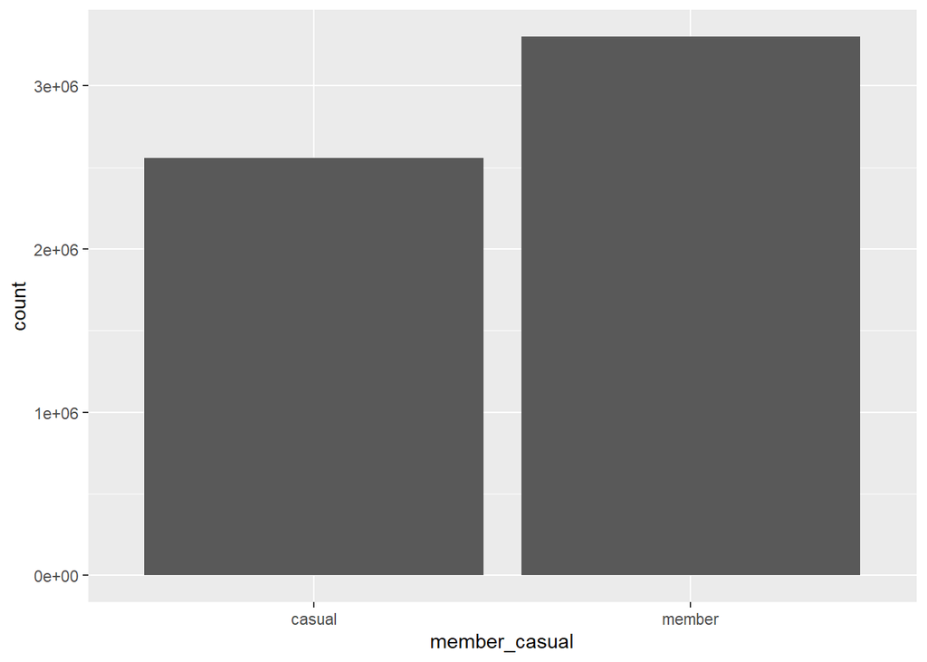

```r
ggplot(trips) +
  geom_bar(aes(member_casual))
```

There are more member riders than casual. Anywhere, almost half of the users are casual riders.

### Bycicle type used by members vs casual riders

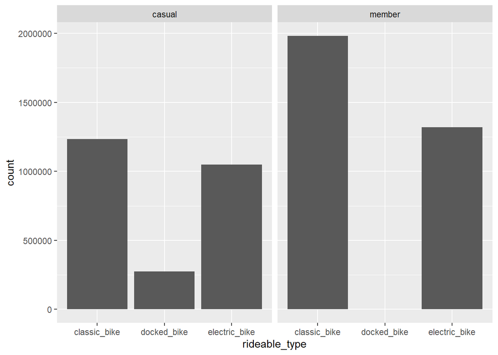

```r
ggplot(trips)+
  geom_bar(aes( x = rideable_type)) + facet_grid(~member_casual)
```

Member riders prefer classic bikes, while casual distribute their use between classic and electric bikes.

### Riders count by month, casual vs member riders

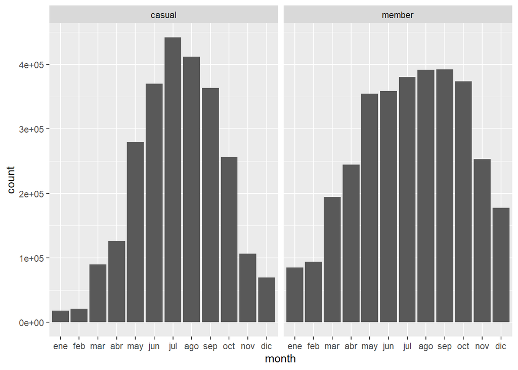

```r
ggplot(trips) +
  geom_bar(aes(x = month)) + facet_grid(~member_casual)
```

Casual riders usage is concentrated mainly in summmer time (between may and october).

### Riders count by week day, casual vs member riders

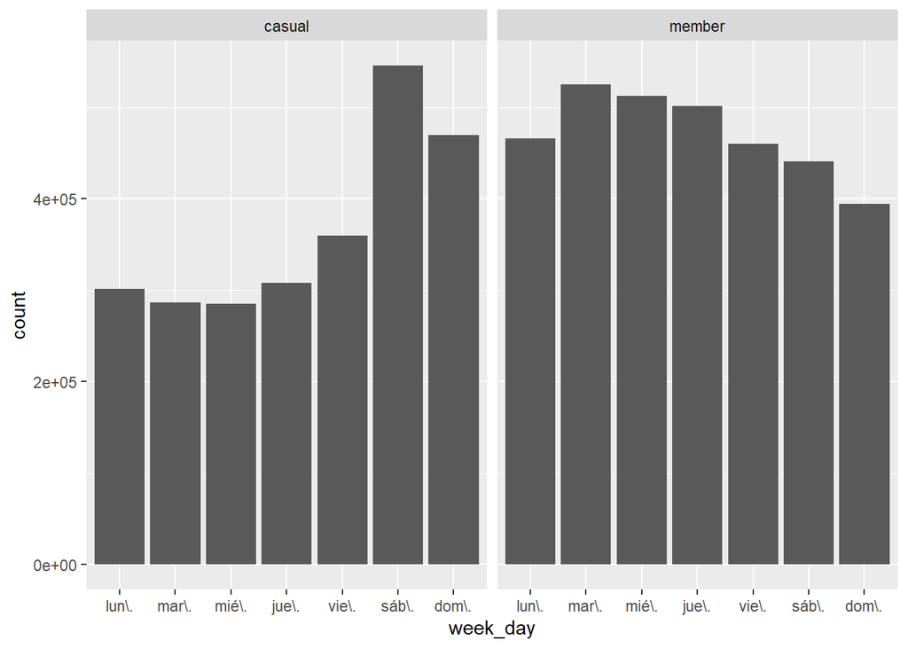

```r
ggplot(trips) +
  geom_bar(aes(x = week_day)) + facet_grid(~member_casual)
```

Casual riders usage is concentrated in weekends.

### Riders count by month day, casual vs member riders

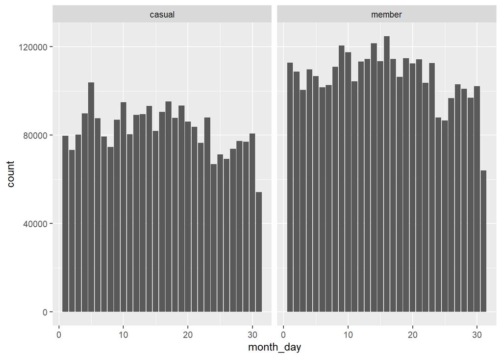

```r
ggplot(trips) +
  geom_bar(aes(x = month_day)) + facet_grid(~member_casual)
```

Casual riders usage is homogeneus during the month.

### Riders count by day hour, casual vs member riders

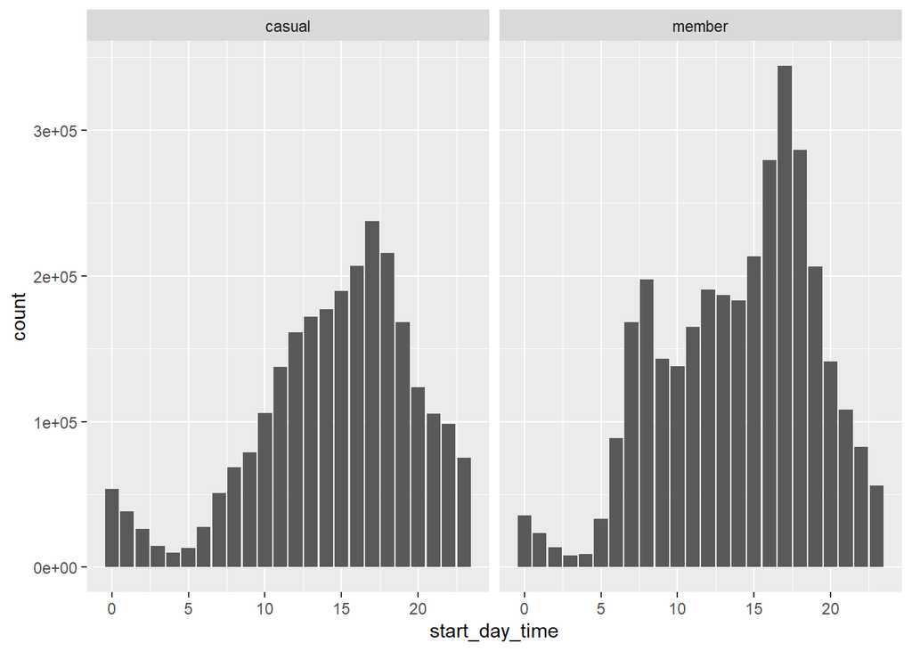

```r
ggplot(trips) +
  geom_bar(aes(x = start_day_time)) + facet_grid(~member_casual)
```

Casual riders usage is concentrated between 11 am to 7 pm.

### Riders count by trip distance

Trip distances are leveraged by outliers. Due to this, is necessary to take out those outliers from the analysis.

```r
trip_dist_Q<- quantile(trips$trip_dist_km, probs = c(.25, .75), na.rm = FALSE)
trip_dist_IQR<- IQR(trips$trip_dist_km) #taking out the outliers with the interquantile range method

trip_dist_clean<-subset(trips,
       trips$trip_dist_km > trip_dist_Q[1]-1.5*trip_dist_IQR &
         trips$trip_dist_km < trip_dist_Q[2]+1.5*trip_dist_IQR)
```

Plotting of the trip distances by user type

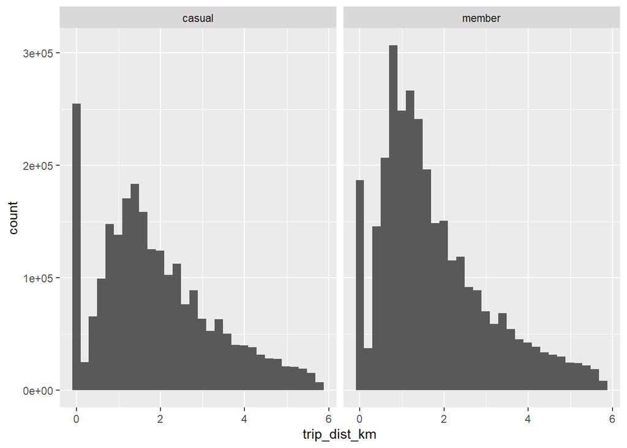

```r
ggplot(trip_dist_clean) +
  geom_histogram(aes(x = trip_dist_km)) + facet_grid(~member_casual)
```

Trip distances are similar for casual and member riders.

[figure not shown]

```r
casual_trips<- filter(trips, member_casual == "casual")
casual_start_stations<- as.data.frame(table(trips$start_station_name,
                                            exclude = ""))
top_casual_st_stations<- arrange(casual_start_stations, desc(Freq))%>%
  slice(1:10)
ggplot(top_casual_st_stations)  +
  geom_col(aes(x = reorder(Var1, Freq), y = Freq)) +
  coord_flip() + labs(x = "Top Casual Riders Stations", y= "Anual Riders")
```

### Main casual riders geolocalization during July

Due to the fact that July is the month of more casual riders usage, it is shown the main geolocation of those users. Briefly, it was plotted the location of the start point of casual riders trips durig July.

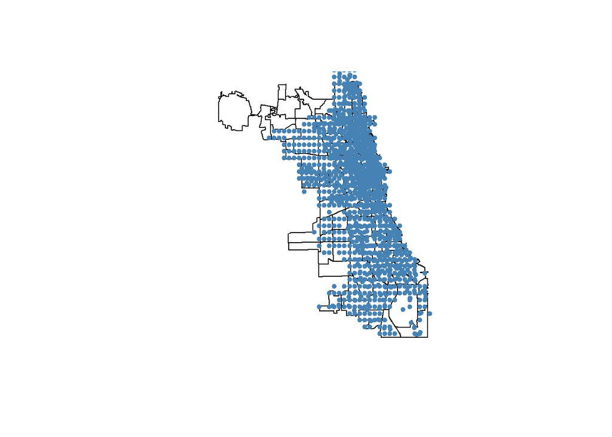

```r
jul_casual_trips<-filter(casual_trips, month == "jul") #filtering July casual riders trips

coordinates(jul_casual_trips) = c("start_lng", "start_lat")
crs.geo1 = CRS("+proj=longlat")
proj4string(jul_casual_trips) = crs.geo1 #converting DF in spatial data

chicago <- readOGR(dsn = "./Map",layer = "geo_export_7f9b79d6-1e5f-4784-be5f-6f2e3a6a2c68") #shapefile downloaded from Chicago webpage
plot(chicago)
points(jul_casual_trips, pch = 20, col = "steelblue")
```